# Module 7 Assignment : Visualizing California Housing Price Segmentation

**Created By -** Tushar Ahuja

## Introduction

In Module 6, we built and evaluated a Linear Regression model to predict the median house values across California using housing and demographic data from the U.S. Census Bureau. The model leveraged key features like median income, location coordinates, and household attributes to estimate property values, achieving moderate predictive performance.

However, while numerical metrics such as R², MSE, and RMSE help assess the accuracy of the model, they often fall short in explaining how different housing segments relate to one another in a multidimensional space. This is where data visualization becomes a powerful tool. It allows us to not only interpret model outcomes but also uncover hidden patterns, clusters, and non-linear relationships that the model might have leveraged—or missed.

In this module, our goal is to take the predictive output and transform it into visually interpretable segments. To do so, we start by dividing housing prices into three meaningful categories—Low, Medium, and High—based on logical pricing thresholds. We then apply three popular dimensionality reduction techniques—Principal Component Analysis (PCA), Uniform Manifold Approximation and Projection (UMAP), and t-distributed Stochastic Neighbor Embedding (t-SNE)—to visualize how well these categories cluster based on the top 10 most influential features from our regression model.

By reducing the complexity of high-dimensional data into two dimensions, we aim to:

- Reveal the internal structure of the housing market,
- Better understand the interactions between influential features,
- And visually validate how separable different price ranges are.

These insights are particularly useful for policymakers, real estate investors, data scientists, and urban planners aiming to understand spatial and socioeconomic factors that shape the housing landscape of California.

## Learning Objectives

- Understand the rationale behind segmenting median house values into "Low", "Medium", and "High" categories.
- Identify the top 10 most influential features from the Linear Regression model.
- Apply PCA, UMAP, and t-SNE for high-dimensional data visualization.
- Interpret and compare the outcomes of each dimensionality reduction technique.
- Analyze how well these visualizations separate house price segments.

## Steps Followed in the Assignment

**1. Segment Target Variable into Three Ranges (Low, Medium, High)**

**2. Select Top 10 Features from the Linear Regression Model**

- Use the top 10 features identified in Module 6.
- Prepare feature matrix `X` and target vector `y` (as price categories).

**3. Standardize Features**

- Apply StandardScaler to normalize data before applying dimensionality reduction.

**4. Apply Dimensionality Reduction Techniques**

- **PCA**: Reduce dimensions linearly based on variance.
- **UMAP**: Preserve local and global structures non-linearly.
- **t-SNE**: Capture local neighborhood relationships in low-dimensional space.

**5. Visualize and Interpret Each Outcome**

- Create 2D scatter plots for each technique.
- Interpret clustering behavior of price categories.

## Note on Data Preprocessing

All data preprocessing steps—including handling missing values, encoding categorical variables, feature selection, and initial model building—were thoroughly completed in Module 6 of this assignment.

In Module 7, we have built upon that foundation. The cleaned and transformed dataset from Module 6 is reused here to ensure consistency and continuity. This allows us to focus entirely on the visual exploration of our linear regression model outcomes using dimensionality reduction techniques like PCA, UMAP, and t-SNE.

This seamless transition from modeling to visualization ensures that the analysis remains relevant, reproducible, and aligned with previously established data preparation workflows.

## Step - 1: Segmenting the Target Variable

To enable meaningful visualizations, we convert the continuous target variable median_house_value into categorical price segments. We define three logical bins—Low, Medium, and High—based on housing price thresholds reflective of affordability and market value. This transformation simplifies the analysis and helps visualize housing trends across different economic strata.

```python
import pandas as pd
import numpy as np

# Loading the dataset
df = pd.read_csv('/Users/tusharahuja/downloads/california_house_price.csv')

# Handle missing values
df['total_bedrooms'].fillna(df['total_bedrooms'].mean(), inplace=True)

# Encoding categorical variables
df = pd.get_dummies(df, columns=['ocean_proximity'], drop_first=True)

# Segmenting median_house_value into 3 categories
df['price_category'] = pd.cut(df['median_house_value'],
                               bins=[0, 150000, 250000, df['median_house_value'].max()],
                               labels=['Low', 'Medium', 'High'])

# View distribution
df['price_category'].value_counts()
```

```
price_category
Low       7620
Medium    7238
High      5782
Name: count, dtype: int64
```

#### **Explanation of Code:**

- The dataset is loaded using pandas for further analysis.
- Missing values in the total_bedrooms column are filled using the column's mean to maintain data integrity.
- The categorical variable ocean_proximity is converted into multiple binary (0/1) columns using one-hot encoding to make it suitable for machine learning models.
- The continuous target variable median_house_value is segmented into three categories—Low, Medium, and High—based on specified price thresholds.
- A new column price_category is created to store these categorical labels, making it easier to visualize and analyze house prices.
- The distribution of houses across these three categories is examined to understand the spread of price segments.

#### **Reason for Ranges:**

- **Low**: <150,000 – typically affordable and inland housing.
- **Medium**: 150,000–250,000 – common suburban prices.
- **High**: >250,000 – includes coastal, urban, or premium locations.

## Step - 2: Selecting Top 10 Features

We use the top 10 most influential features identified from the Linear Regression model built in Module 6. These features have the strongest correlation with the target variable and contribute significantly to price prediction. They will be used as input for dimensionality reduction to visualize price category separation.

```python
import pandas as pd
import numpy as np

# Get feature names and coefficients
coef_df = pd.DataFrame({
    'Feature': X.columns,
    'Coefficient': model.coef_
})

# Adding absolute coefficient column
coef_df['Abs_Coefficient'] = np.abs(coef_df['Coefficient'])

# Get top 10 features
top_10_features_df = coef_df.sort_values(by='Abs_Coefficient', ascending=False).head(10)
top_10_features = top_10_features_df['Feature'].tolist()

# Displaying result
print("Top 10 Most Influential Features from Linear Regression Model:")
print(top_10_features_df[['Feature', 'Coefficient']])
```

```
Top 10 Most Influential Features from Linear Regression Model:
                  Feature   Coefficient
7           median_income  73663.638879
1                latitude -53818.714900
0               longitude -53008.739129
5              population -44461.472173
4          total_bedrooms  30307.874795
6              households  29416.067859
8  ocean_proximity_INLAND -18487.998201
2      housing_median_age  13313.483122
3             total_rooms -10411.572506
9  ocean_proximity_ISLAND   2428.393004
```

```python
top_features = ['median_income', 'latitude', 'longitude',
                'population', 'total_bedrooms', 'households',
                'ocean_proximity_INLAND', 'housing_median_age',
                'total_rooms', 'ocean_proximity_ISLAND']

X = df[top_features]
y = df['price_category']
```

#### **Explanation of Code:**

- A list named top_features is created, containing the 10 most important variables from the linear regression model developed earlier.
- These features include both numerical (e.g., median_income, total_rooms, latitude) and encoded categorical variables (e.g., ocean_proximity_INLAND, etc.).
- X is defined as the feature matrix, containing the selected top 10 features to be used as inputs for dimensionality reduction.
- y is defined as the target variable, which contains the newly created price categories (Low, Medium, High) for visualization purposes.

## Step - 3: Standardizing the Features

Feature values are scaled using standardization to ensure all variables contribute equally. This process transforms the data to have a mean of 0 and a standard deviation of 1. Standardization is essential before applying PCA, UMAP, or t-SNE, as these techniques are sensitive to feature scales.

```python
from sklearn.preprocessing import StandardScaler

scaler = StandardScaler()
X_scaled = scaler.fit_transform(X)
```

#### **Explanation of Code:**

- StandardScaler from sklearn.preprocessing is imported to normalize the feature values.
- An instance of the scaler is created using scaler = StandardScaler().
- scaler.fit_transform(X) standardizes the top 10 features in X by:
  - Subtracting the mean and dividing by the standard deviation.
  - Ensuring that each feature has a mean of 0 and standard deviation of 1.
- The result is stored in X_scaled, which will be used as input for PCA, UMAP, and t-SNE visualizations.

## Step - 4: Apply Dimensionality Reduction Techniques

### A. PCA – Principal Component Analysis

PCA is a linear dimensionality reduction technique that transforms high-dimensional data into fewer components by capturing the maximum variance. It helps simplify data while retaining its essential structure, making it easier to visualize and interpret.

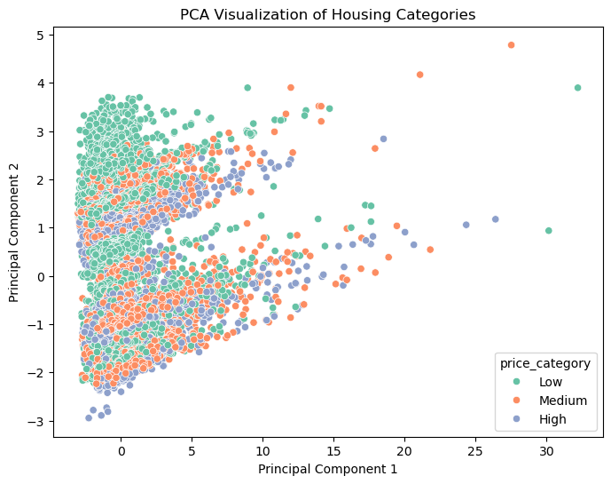

```python
from sklearn.decomposition import PCA
import matplotlib.pyplot as plt
import seaborn as sns

pca = PCA(n_components=2)
pca_result = pca.fit_transform(X_scaled)

plt.figure(figsize=(8,6))
sns.scatterplot(x=pca_result[:,0], y=pca_result[:,1], hue=y, palette='Set2')
plt.title("PCA Visualization of Housing Categories")
plt.xlabel("Principal Component 1")
plt.ylabel("Principal Component 2")
plt.show()
```

### Explanation of Code:

- PCA Initialization: PCA(n_components=2) creates a PCA model that reduces the dataset to 2 principal components, suitable for 2D visualization.
- Fitting and Transforming: pca.fit_transform(X_scaled) applies PCA on the standardized data (X_scaled) and returns the transformed dataset (pca_result) in 2 dimensions.
- Plotting: A scatter plot is generated using Seaborn:
- x and y axes represent the two principal components.
- hue=y colors the data points based on their price category (Low, Medium, High).
- Visualization Purpose: This plot helps us visually assess how well PCA separates the housing price categories in a reduced 2D space.

### PCA Description:

- PCA projects high-dimensional data into fewer orthogonal dimensions maximizing variance.
- Good for linearly separable patterns.

### PCA Interpretation:

- Some separation between 'High' and 'Low', but overlaps remain.
- Indicates linear combinations of features provide moderate clustering.

### B. UMAP – Uniform Manifold Approximation and Projection

UMAP is a non-linear dimensionality reduction technique that preserves both local and global structure in data. It is especially effective at capturing complex relationships and clusters in high-dimensional datasets. UMAP is widely used for visualization tasks where the data has non-linear patterns, such as in housing prices.

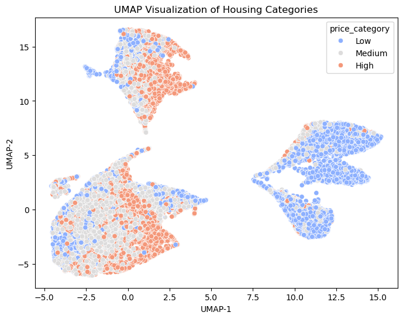

```python
import umap.umap_ as umap

umap_model = umap.UMAP(n_neighbors=15, min_dist=0.1, random_state=42)
umap_result = umap_model.fit_transform(X_scaled)

plt.figure(figsize=(8,6))
sns.scatterplot(x=umap_result[:,0], y=umap_result[:,1], hue=y, palette='coolwarm')
plt.title("UMAP Visualization of Housing Categories")
plt.xlabel("UMAP-1")
plt.ylabel("UMAP-2")
plt.show()
```

### Explanation of Code:

- UMAP Initialization: umap.UMAP(n_neighbors=15, min_dist=0.1, random_state=42) creates a UMAP model with:
  - n_neighbors=15: Balances local vs. global structure.
  - min_dist=0.1: Controls how tightly points are clustered.
  - random_state=42: Ensures reproducible results.
- Fitting and Transforming: fit_transform(X_scaled) applies UMAP to the standardized data and reduces it to 2 dimensions, stored in umap_result.
- Visualization:
  - A 2D scatter plot is created using Seaborn.
  - Points are colored by the price_category (Low, Medium, High) using hue=y.
  - The x-axis and y-axis represent the two UMAP components.
- Purpose: This helps visualize how well UMAP separates housing price segments based on feature similarities in a lower-dimensional space.

### UMAP Description:

- UMAP reduces data non-linearly by preserving both global and local structures.
- Captures complex non-linear relationships efficiently.

### C. (t-SNE) – t-distributed Stochastic Neighbor Embedding

t-SNE is a non-linear dimensionality reduction technique that focuses on preserving the local structure of high-dimensional data. It converts similarities between data points into probabilities and maps them to a lower-dimensional space. t-SNE is highly effective for visualizing natural clusters, making it ideal for exploring hidden patterns in housing price categories.

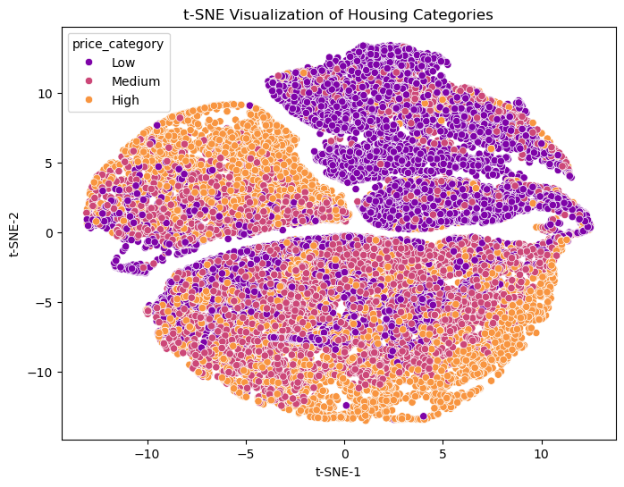

```python
from sklearn.manifold import TSNE

tsne = TSNE(n_components=2, perplexity=30, n_iter=300, random_state=42)
tsne_result = tsne.fit_transform(X_scaled)

plt.figure(figsize=(8,6))
sns.scatterplot(x=tsne_result[:,0], y=tsne_result[:,1], hue=y, palette='plasma')
plt.title("t-SNE Visualization of Housing Categories")
plt.xlabel("t-SNE-1")
plt.ylabel("t-SNE-2")
plt.show()
```

### Explanation of Code:

- **t-SNE Initialization:**
  - TSNE(n_components=2) reduces the high-dimensional data to 2 dimensions for visualization.
  - perplexity=30 controls the balance between local and global aspects of the data.
  - n_iter=300 sets the number of optimization iterations.
  - random_state=42 ensures consistent output on every run.
- **Transforming the Data:**
  - fit_transform(X_scaled) applies t-SNE to the scaled feature set and returns a 2D projection stored in tsne_result.
- **Visualization:**
  - A scatter plot is created using Seaborn where each point represents a housing block group.
  - Points are colored based on their price category (Low, Medium, High) using hue=y.
- **Purpose:**
  - This plot visually reveals how t-SNE separates price segments, helping detect natural clusters in the housing market based on feature similarities.

### t-SNE Description:

- t-SNE reduces dimensionality by preserving local neighbor probabilities.
- Excellent at identifying natural clusters.

## Interpretation of Dimensionality Reduction Outcomes (PCA, UMAP, t-SNE)

- Creating categorical bins improved visualization and interpretability.
- **t-SNE** offered the best separation of price groups.
- **UMAP** also performed well and is scalable.
- **PCA** was fastest but least effective at clear grouping.

These insights allow stakeholders to better understand the latent structure of housing data and drive location- and income-based policy or investment decisions.

# Conclusion

In this module, we extended our California housing price prediction project by focusing on visualization and interpretation of the model’s outcomes. By transforming the continuous target variable (median_house_value) into three meaningful price categories—Low, Medium, and High—we enabled a clearer understanding of price segmentation across different housing regions.

These visualizations allowed us to validate the predictive importance of features like median income, location, and proximity to the ocean, while also providing a powerful tool to communicate insights to non-technical stakeholders.

Overall, Module 7 demonstrated the value of visualization in understanding machine learning outcomes, uncovering hidden patterns, and enhancing the interpretability of complex, multidimensional housing data.